# Atividade - Aula 11 - 24 11 23

```r
library(yfR)
library(tidyverse)
library(forecast)
library(fGarch)
library(MTS)
```

# Exercício 1

Using package yfR (M. Perlin 2023), download data for the SP500 (ticker ^GSPC) between 2015 and today. Estimate a ARIMA (1, 0, 0) for the adjusted returns. What is the value of the autoregressive parameter?

```r
df_gspc <- yf_get('^GSPC',
               first_date = '2015-01-01',
               last_date = '2023-11-24',
               be_quiet = T)

modelo1 <- stats::arima(df_gspc$ret_adjusted_prices,
                        order = c(1, 0, 0))

modelo1
```

```
Call:
stats::arima(x = df_gspc$ret_adjusted_prices, order = c(1, 0, 0))

Coefficients:
          ar1  intercept
      -0.1462      4e-04
s.e.   0.0209      2e-04

sigma^2 estimated as 0.0001313:  log likelihood = 6825.9,  aic = -13645.8
```

**Resposta:** Valor do parâmetro autoregressivo: -0.1462

# Exercício 2

Using same package, download data for the FTSE between 2010 and today. However, download data for daily, monthly and yeary observations. Estimate a ARIMA(1, 0, 1) for each of the time series of returns. Can you find any difference in the estimated coefficients?

```r
df_ftse_daily <- yf_get('^FTSE',
               first_date = '2015-01-01',
               last_date = '2023-11-24',
               be_quiet = T, freq_data = 'daily')

df_ftse_monthly <- yf_get('^FTSE',
               first_date = '2015-01-01',
               last_date = '2023-11-24',
               be_quiet = T, freq_data = 'monthly')

df_ftse_yearly <- yf_get('^FTSE',
               first_date = '2015-01-01',
               last_date = '2023-11-24',
               be_quiet = T, freq_data = 'yearly')

modelo_daily <- stats::arima(df_ftse_daily$ret_adjusted_prices,
                        order = c(1, 0, 1))

modelo_monthly <- stats::arima(df_ftse_monthly$ret_adjusted_prices,
                        order = c(1, 0, 1))

modelo_yearly <-   stats::arima(df_ftse_yearly$ret_adjusted_prices,
                        order = c(1, 0, 1))


modelo_daily
```

[output not shown]

```
          ar1      ma1  intercept
      -0.0078  -0.0082      1e-04
s.e.      NaN      NaN      2e-04

sigma^2 estimated as 0.0001056:  log likelihood = 7095.41,  aic = -14182.82
```

```r
modelo_monthly
```

```
Call:
stats::arima(x = df_ftse_monthly$ret_adjusted_prices, order = c(1, 0, 1))

Coefficients:
         ar1      ma1  intercept
      0.4508  -0.5424     0.0016
s.e.  0.8794   0.8293     0.0029

sigma^2 estimated as 0.001292:  log likelihood = 202.12,  aic = -396.23
```

```r
modelo_yearly
```

```
Call:
stats::arima(x = df_ftse_yearly$ret_adjusted_prices, order = c(1, 0, 1))

Coefficients:
          ar1      ma1  intercept
      -0.4129  -1.0000     0.0166
s.e.   0.3545   0.3785     0.0062

sigma^2 estimated as 0.00348:  log likelihood = 9.79,  aic = -11.57
```

**Resposta:**

Em geral os coeficientes são bem diferentes, entre monthly e yearly o AR(1) ficou em magnitude semelhante, mas com sinal invertido, enquanto que no coeficiente MA(1) os valores possuem mesmo sinal mas valores de uma razão próximo a 2x.

Para dados diários houve aviso de NAs. Não sei o motivo.

# Exercício 3

Using same data from exercise 1, use function forecast::auto.arima() to estimate a ARIMA model with automatic selection of lags. What is the chosem model?

```r
autoarima_gspc <- forecast::auto.arima(
  x = df_gspc$ret_adjusted_prices)

autoarima_gspc
```

```
Series:
ARIMA(5,0,2) with non-zero mean

Coefficients:
          ar1      ar2      ar3      ar4     ar5     ma1   ma2   mean
      -1.6660  -0.8132  -0.0078  -0.0038  0.0176  1.5750  0.70  4e-04
s.e.   0.0744   0.0781   0.0447   0.0427  0.0286  0.0715  0.06  2e-04

sigma^2 = 0.000125:  log likelihood = 6885.18
AIC=-13752.35   AICc=-13752.27   BIC=-13700.93
```

**Resposta:** Modelo selecionado no auto.arima foi ARIMA(5,0,2).

# Exercício 4

Using package fGarch (Wuertz et al. 2023), simulate 10000 observations of a GARCH(1,1) model with the following specification:

yt=0.015−0.15yt−1+ϵt

ϵt ∼N(0,ht)

ht =0.001+0.1ϵ2t−1+0.85ht−1

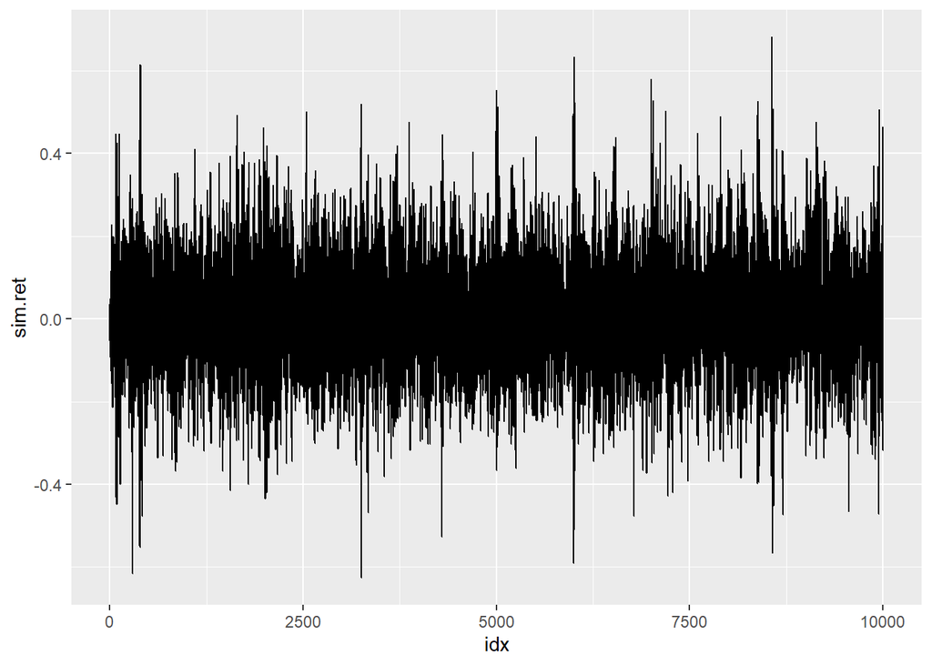

```r
# parametros a serem usados
parametros_garch = list(
  omega = 0.001,
  alpha = 0.1,
  beta = 0.85,
  mu = 0.015,
  ar = -0.15
)

# criar especificacao do modelo
modelo_garch_simulado <- fGarch::garchSpec(
  model = parametros_garch)

# seed par amanter reprodutibilidade
set.seed(1234)

n_sim <- 10000
sim_garch = fGarch::garchSim(modelo_garch_simulado, n = n_sim)

df_garch_sim <- tibble(
    sim.ret = sim_garch$garch,
    idx=seq_along(sim_garch$garch))

ggplot(df_garch_sim, aes(x=idx, y=sim.ret)) +
  geom_line()
```

# Exercício 5

Using the simulated data from previous exercise, estimate a GARCH(1, 1) model with fGarch::garchFit(). Do the estimated coefficients match the ones from the simulation?

```r
modelo_garch_estimado <- fGarch::garchFit(
  data = sim_garch,
  formula = ~ arma(1,0) + garch(1,1),
  trace = FALSE
)

print(modelo_garch_estimado)
```

```
Title:
 GARCH Modelling

Call:
 fGarch::garchFit(formula = ~arma(1, 0) + garch(1, 1), data = sim_garch,
    trace = FALSE)

Mean and Variance Equation:
 data ~ arma(1, 0) + garch(1, 1)
<environment: 0x000002140f97d898>
 [data = sim_garch]

Conditional Distribution:
 norm

Coefficient(s):
        mu         ar1       omega      alpha1       beta1
 0.0150661  -0.1505519   0.0010251   0.0952311   0.8493328

Std. Errors:
 based on Hessian

Error Analysis:
         Estimate  Std. Error  t value Pr(>|t|)
mu      0.0150661   0.0012472   12.080  < 2e-16 ***
ar1    -0.1505519   0.0103452  -14.553  < 2e-16 ***
omega   0.0010251   0.0001257    8.155 4.44e-16 ***
alpha1  0.0952311   0.0069625   13.678  < 2e-16 ***
beta1   0.8493328   0.0112316   75.620  < 2e-16 ***
---
Signif. codes:  0 '***' 0.001 '**' 0.01 '*' 0.05 '.' 0.1 ' ' 1

Log Likelihood:
 6130.009    normalized:  0.6130009

Description:
 Fri Nov 24 18:46:40 2023 by user: luisg
```

**Resposta:**

Comparando os parâmetros:

[output not shown]

O modelo estimou valores muito próximos dado que o tamanho da amostra usada foi de 10.000 observações. Quanto mais observações melhor a estimativa do modelo.

# Exercício 6

Using package yfR, download data for the IBOVESPA index (ticker ^BVSP) between 2015 and today. Test the existence of arch effects in 1) prices series and 2) in the returns series. Report an discuss both results.

```r
df_ibov <- yf_get('^BVSP',
               first_date = '2015-01-01',
               last_date = '2023-11-24',
               be_quiet = T)

df_ibov <- df_ibov |>
  na.omit()
```

## Test the existence of arch effects in 1) prices series

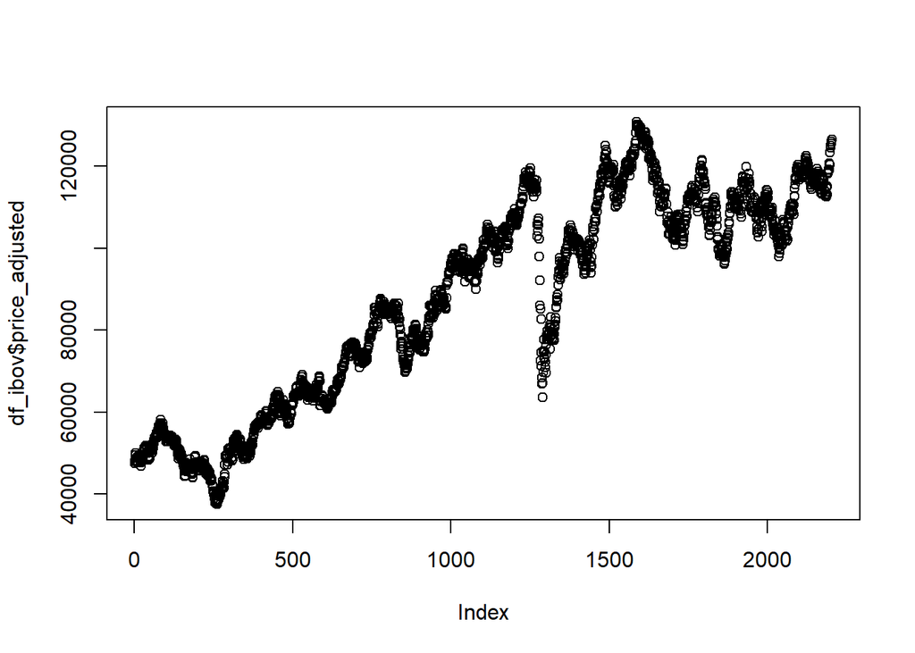

```r
plot(df_ibov$price_adjusted)
```

```r
MTS::archTest(
  rt = df_ibov$price_adjusted
)
```

```
Q(m) of squared series(LM test):
Test statistic:  21425.47  p-value:  0
Rank-based Test:
Test statistic:  21329.91  p-value:  0
```

## Test the existence of arch effects in 2) in the returns series

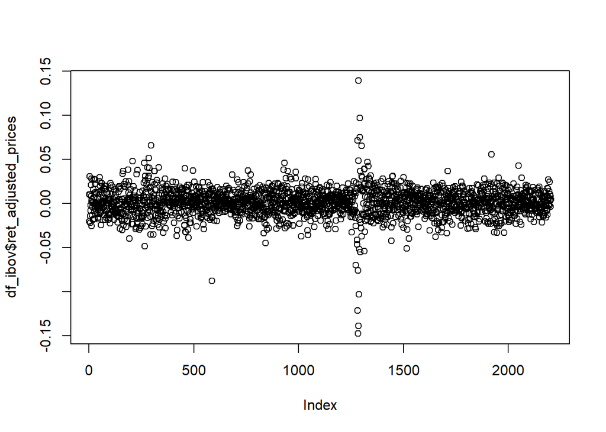

```r
plot(df_ibov$ret_adjusted_prices)
```

```r
MTS::archTest(
  rt = df_ibov$ret_adjusted_prices
)
```

```
Q(m) of squared series(LM test):
Test statistic:  2821.896  p-value:  0
Rank-based Test:
Test statistic:  121.9522  p-value:  0
```

**Resposta:** Ambos testes retornam valores da estatística de teste altos e, portanto, p valores baixos. Em ambos os casos existe a volatilidade na variância e assim são processos que podem ser modelos por ARCH.

# Exercício 7

For the same data used in 4, estimate a GARCH(1, 1) for the adjusted returns. Report the model and its coefficients in the screen of R.

** Imagino que aqui seria mesmos dados do exercício 6 (dados IBOVESPA).

```r
df_ibov_ts <- fBasics::as.timeSeries(df_ibov)

modelo_garch_estimado_ibov <- fGarch::garchFit(
  data = df_ibov_ts ,
  formula = ret_adjusted_prices ~ arma(1,0) + garch(1,1),
  trace = FALSE)

print(modelo_garch_estimado_ibov)
```

```
Title:
 GARCH Modelling

Call:
 fGarch::garchFit(formula = ret_adjusted_prices ~ arma(1, 0) +
    garch(1, 1), data = df_ibov_ts, trace = FALSE)

Mean and Variance Equation:
 ret_adjusted_prices ~ arma(1, 0) + garch(1, 1)
 [data = df_ibov_ts]

Conditional Distribution:
 norm

Coefficient(s):
         mu          ar1        omega       alpha1        beta1
 8.0362e-04  -2.1573e-02   9.3822e-06   7.9321e-02   8.7518e-01

Std. Errors:
 based on Hessian

Error Analysis:
         Estimate  Std. Error  t value Pr(>|t|)
mu      8.036e-04   2.794e-04    2.877  0.00402 **
ar1    -2.157e-02   2.284e-02   -0.944  0.34493
omega   9.382e-06   2.325e-06    4.036 5.44e-05 ***
alpha1  7.932e-02   1.216e-02    6.523 6.89e-11 ***
beta1   8.752e-01   1.926e-02   45.435  < 2e-16 ***
---
Signif. codes:  0 '***' 0.001 '**' 0.01 '*' 0.05 '.' 0.1 ' ' 1

Log Likelihood:
 6307.161    normalized:  2.862987

Description:
 Fri Nov 24 18:46:42 2023 by user: luisg
```